# How to write a custom wrangling function

R package build

2021-03-14

This post comes from a [Stackoverflow question](https://stackoverflow.com/questions/4350440/split-data-frame-string-column-into-multiple-columns) that I’ve revisited numerous times over the years.

The original question:

> **Stackoverflow: Split data frame string column into multiple columns**

> *I’d like to take data of the form*

```r
before = data.frame(attr = c(1, 30, 4, 6),
                    type = c('foo_and_bar',
                             'foo_and_bar_2'))

  attr          type
1    1   foo_and_bar
2   30 foo_and_bar_2
3    4   foo_and_bar
4    6 foo_and_bar_2
```

> *and use `split()` on the column “`type`” from above to get something like this:*

```r
  attr type_1 type_2
1    1    foo    bar
2   30    foo  bar_2
3    4    foo    bar
4    6    foo  bar_2
```

#### Load packages

Let’s load the `tidyverse` and get started!

```r
library(tidyverse)
```

#### Create some messy data

Below is an example `tibble` with a jumbled `name` column (`JJJSBefore`) similar to the one above. I chose to use commas and spaces instead of underscores because I find them a little easier to read.

```r
JJJSBefore <- tibble::tribble(
     ~value,                       ~name,
        29L,                      "John",
        91L,               "John, Jacob",
        39L, "John, Jacob, Jingleheimer",
        28L,     "Jingleheimer, Schmidt",
        12L,              "JJJ, Schmidt")
```

| value | name |
| --- | --- |
| 29 | John |
| 91 | John, Jacob |
| 39 | John, Jacob, Jingleheimer |
| 28 | Jingleheimer, Schmidt |
| 12 | JJJ, Schmidt |

### A ‘not quite’ solution

One possible solution is to combine `dplyr::mutate()`, `stringr::str_split()`, and `tidyr::unnest()`.

```r
JJJSBefore %>%
        dplyr::mutate(name =
    # 1) split this on the ", " pattern
             stringr::str_split(string = name,
                                pattern = ", ")) %>%
    # 2) convert output from str_split across rows
        tidyr::unnest(name)
```

| value | name |
| --- | --- |
| 29 | John |
| 91 | John |
| 91 | Jacob |
| 39 | John |
| 39 | Jacob |
| 39 | Jingleheimer |
| 28 | Jingleheimer |
| 28 | Schmidt |
| 12 | JJJ |
| 12 | Schmidt |

This gets the data into a tidy format, but it would require some additional wrangling steps to get the data back into the two columns the question was looking for.

Fortunately, this particular question was posed 9 years and 6 months ago at the time of this writing, so there are quite a few solutions listed. I liked the approach [Yannis-P](https://stackoverflow.com/users/1885713/yannis-p) took because 1) it offers a `tidyverse` solution *and* 2) it’s written as a function.

I’ve copied Yannis-P’s comment on the proposed solution below:

> *We can’t use `dplyr` `separate()` because we don’t know the number of the result columns before the split, so I have then created a function that uses `stringr` to split a column, given the pattern and a name prefix for the generated columns.*

### Original `split_into_multiple()`

Here is the function:

```r
split_into_multiple <- function(column, pattern = ", ", into_prefix){
  cols <- str_split_fixed(column, pattern, n = Inf)
  # Sub out the ""'s returned by filling the matrix
  # to the right, with NAs which are useful
  cols[which(cols == "")] <- NA

  cols <- as.tibble(cols)
  # name the 'cols' tibble as 'into_prefix_1',
  # 'into_prefix_2', ..., 'into_prefix_m'
  # where m = # columns of 'cols'
  m <- dim(cols)[2]

  names(cols) <- paste(into_prefix, 1:m, sep = "_")

  return(cols)
}
```

### How it works

Let’s break down the `split_into_multiple()` function’s components:

The first step takes an input column and applies the `stringr::str_split_fixed()` function, which returns [“a character matrix with `n` columns.”](https://stringr.tidyverse.org/reference/str_split.html)

```r
cols <- stringr::str_split_fixed(column, pattern, n = Inf)
```

By setting `n` to `Inf`, the number of items to split the `string` into is infinite.

```r
cols <- stringr::str_split_fixed(string = JJJSBefore$name,
                                 pattern = ", ",
                                 n = Inf)
cols
##      [,1]           [,2]      [,3]
## [1,] "John"         ""        ""
## [2,] "John"         "Jacob"   ""
## [3,] "John"         "Jacob"   "Jingleheimer"
## [4,] "Jingleheimer" "Schmidt" ""
## [5,] "JJJ"          "Schmidt" ""
```

After the `name` column is split into a character matrix of split columns (`cols`), the `split_into_multiple()` function uses [`base::which()`](https://stat.ethz.ch/R-manual/R-devel/library/base/html/which.html) to identify the empty columns in the matrix.

```r
base::which(cols == "")
## [1]  6 11 12 14 15
```

`base::which()` returns a numerical vector that correspond to the empty columns in the `cols` matrix.

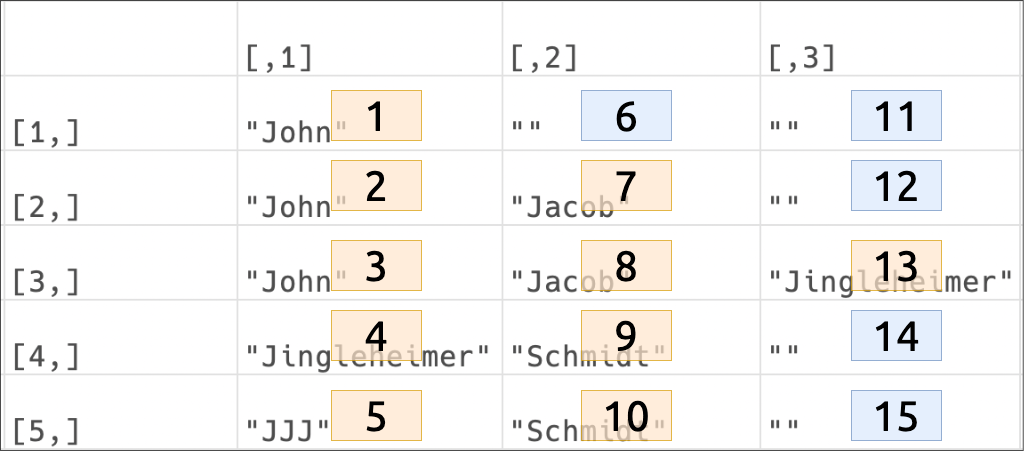

The `split_into_multiple()` function subsets the `cols` matrix with the output from `base::which(cols == "")` and assigns `NA`s to the locations identified above.

```r
cols[base::which(cols == "")] <- NA
cols
##      [,1]           [,2]      [,3]
## [1,] "John"         NA        NA
## [2,] "John"         "Jacob"   NA
## [3,] "John"         "Jacob"   "Jingleheimer"
## [4,] "Jingleheimer" "Schmidt" NA
## [5,] "JJJ"          "Schmidt" NA
```

Next, we need a `tibble`, not a matrix, so `split_into_multiple()` converts `cols` into a tibble with `cols <- as.tibble(cols)`.

```r
cols <- tibble::as.tibble(cols)
cols
```

### `as.tibble()` warning

`as.tibble()` throws the following warning,

```
1: `as.tibble()` is deprecated as of tibble 2.0.0.
Please use `as_tibble()` instead.
The signature and semantics have changed, see `?as_tibble`.
```

I’ll replace it with [`as_tibble()` from `tibble`](https://tibble.tidyverse.org/reference/as_tibble.html).

```r
cols <- tibble::as_tibble(cols, .name_repair = "universal")
cols
```

### `as_tibble()` warning

Now `tibble::as_tibble()` is throwing this warning,

```
2: The `x` argument of `as_tibble.matrix()` must have column
names if  `.name_repair` is omitted as of tibble 2.0.0.
Using compatibility `.name_repair`.
```

If I supply the `.name_repair = "universal"` argument, I get the following column names:

| ...1 | ...2 | ...3 |
| --- | --- | --- |
| John | NA | NA |
| John | Jacob | NA |
| John | Jacob | Jingleheimer |
| Jingleheimer | Schmidt | NA |
| JJJ | Schmidt | NA |

This will likely be an issue down the road, so I’ll address it when I make some adjustments to the `split_into_multiple()` function.

Now we have a `tibble`, but we’re missing the original `value` column from `JJJSBefore` (see below).

| value | name |
| --- | --- |
| 29 | John |
| 91 | John, Jacob |
| 39 | John, Jacob, Jingleheimer |
| 28 | Jingleheimer, Schmidt |
| 12 | JJJ, Schmidt |

`split_into_multiple()` then takes the second value from the [`base::dim()`](https://stat.ethz.ch/R-manual/R-devel/library/base/html/dim.html) function (which is short for `dim`ensions).

The second number from `base::dim()` is the number of columns in the `cols` tibble,

```r
m <- base::dim(cols)[2]
m
## [1] 3
```

I can also get this with [`base::ncols()`](https://stat.ethz.ch/R-manual/R-devel/library/base/html/nrow.html)

```r
base::ncol(cols)
## [1] 3
```

Finally, `split_into_columns()` uses `base::paste()` to combine `m` with `into_prefix` to create the new column `base::names()` (separated by an underscore `"_"`).

The `return()` value is `cols` with the new names.

```r
into_prefix <- "name"
base::paste(into_prefix, 1:m, sep = "_")
## [1] "name_1" "name_2" "name_3"
```

Put all together, the function works like so,

```r
split_into_multiple(column = JJJSBefore$name,
                    pattern = ", ",
                    into_prefix = "name") -> JJJAfter
JJJAfter
```

| name_1 | name_2 | name_3 |
| --- | --- | --- |
| John | NA | NA |
| John | Jacob | NA |
| John | Jacob | Jingleheimer |
| Jingleheimer | Schmidt | NA |
| JJJ | Schmidt | NA |

### Address `tibble` warnings

The `as_tibble()`/`as.tibble()` warnings can be addressed by assigning column names with `base::colnames()` to the matrix *before* converting this into a tibble.

```r
# create cols matrix
cols <- str_split_fixed(JJJSBefore$name,
                        pattern = ", ",
                        n = Inf)
# replace "" with NAs
cols[which(cols == "")] <- NA
# get cols
m <- dim(cols)[2]
# assign names
into_prefix <- "name"
colnames(cols) <- paste(into_prefix, 1:m, sep = "_")
# create tibble
cols <- as_tibble(cols)
cols
```

| name_1 | name_2 | name_3 |
| --- | --- | --- |
| John | NA | NA |
| John | Jacob | NA |
| John | Jacob | Jingleheimer |
| Jingleheimer | Schmidt | NA |
| JJJ | Schmidt | NA |

### Add arguments

I’ll also add a few arguments:

- an argument for data (`data =`),
- a default pattern argument (`pattern = [^[:alnum:]]+`),
- `dplyr::bind_cols()` to combine the new output columns with the original input `data.frame`/`tibble`, and
- I changed the names of the inputs to have an `in_` prefix, and the outputs to have an `out_` prefix

## New `split_into_multiple()`

My adjusted `split_into_multiple()` function is below.

```r
split_into_multiple <- function(data, col, pattern = "[^[:alnum:]]+", into_prefix){
  # use regex for pattern, or whatever is provided
  in_pattern <- pattern
  # convert data to tibble
  in_data <- tibble::as_tibble(data)
  # convert col to character vector
  in_col <- base::as.character(col)
  # split columns into character matrix
  out_cols <- stringr::str_split_fixed(in_data[[in_col]],
                                       pattern = in_pattern,
                                       n = Inf)
  # replace NAs in matrix
  out_cols[base::which(out_cols == "")] <- NA
  # get number of cols
  m <- base::dim(out_cols)[2]
  # assign column names
  base::colnames(out_cols) <- base::paste(into_prefix, 1:m, sep = "_")
  # convert to tibble
  out_cols <- tibble::as_tibble(out_cols)
  # bind cols together
  out_tibble <- dplyr::bind_cols(in_data, out_cols)
  # return the out_tibble
  return(out_tibble)
}
```

Now I’ll test `split_into_multiple()` with `JJJSBefore` and see what I get:

```r
JJJSBefore %>%
  split_into_multiple(data = .,
                      col = "name",
                      into_prefix = "name") -> JJJAfter
JJJAfter
```

| value | name | name_1 | name_2 | name_3 |
| --- | --- | --- | --- | --- |
| 29 | John | John | NA | NA |
| 91 | John, Jacob | John | Jacob | NA |
| 39 | John, Jacob, Jingleheimer | John | Jacob | Jingleheimer |
| 28 | Jingleheimer, Schmidt | Jingleheimer | Schmidt | NA |
| 12 | JJJ, Schmidt | JJJ | Schmidt | NA |

**GREAT!** It works! But I should test `split_into_multiple()` on a few more examples.

```r
Before
```

| attr | type |
| --- | --- |
| 1 | foo_and_bar |
| 30 | foo_and_bar_2 |
| 4 | foo_and_bar_2_and_bar_3 |
| 6 | foo_and_bar |

```r
Before %>%
  split_into_multiple(data = .,
                      col = "type",
                      pattern = "_and_",
                      into_prefix = "type")
```

| attr | type | type_1 | type_2 | type_3 |
| --- | --- | --- | --- | --- |
| 1 | foo_and_bar | foo | bar | NA |
| 30 | foo_and_bar_2 | foo | bar_2 | NA |
| 4 | foo_and_bar_2_and_bar_3 | foo | bar_2 | bar_3 |
| 6 | foo_and_bar | foo | bar | NA |

So far, so good!

What if there is a `data.frame`/`tibble` with a bunch of different characters we need to split on? I can test these data in the `WorseThanBefore` data below.

```r
WorseThanBefore <- tibble::tribble(
     ~attr,                     ~type,
        1L,                "foo, bar",
       30L,               "foo-bar/2",
        4L, "foo...bar...2...bar...3",
        6L,               "foo | bar")
WorseThanBefore
```

| attr | type |
| --- | --- |
| 1 | foo, bar |
| 30 | foo-bar/2 |
| 4 | foo...bar...2...bar...3 |
| 6 | foo \| bar |

We’ll use `split_into_multiple()` on `WorseThanBefore`, but omit the argument for `pattern`.

```r
WorseThanBefore %>%
    split_into_multiple(data = .,
                      col = "type",
                      into_prefix = "type")
```

| attr | type | type_1 | type_2 | type_3 | type_4 | type_5 |
| --- | --- | --- | --- | --- | --- | --- |
| 1 | foo, bar | foo | bar | NA | NA | NA |
| 30 | foo-bar/2 | foo | bar | 2 | NA | NA |
| 4 | foo...bar...2...bar...3 | foo | bar | 2 | bar | 3 |
| 6 | foo \| bar | foo | bar | NA | NA | NA |

```r
JJJSBefore %>%
  split_into_multiple(data = .,
                      col = "name",
                      into_prefix = "name") %>%
  dplyr::select(value, dplyr::contains("name_"))
```

| value | name_1 | name_2 | name_3 |
| --- | --- | --- | --- |
| 29 | John | NA | NA |
| 91 | John | Jacob | NA |
| 39 | John | Jacob | Jingleheimer |
| 28 | Jingleheimer | Schmidt | NA |
| 12 | JJJ | Schmidt | NA |

### In closing

This `split_into_multiple()` function has been really helpful for me in the last few projects I’ve been working on. I hope you can use it too!

#### Noteworthy non-`tidyverse` alternatives

I also liked the `cSplit()` function from the [`splitstackshape` package](https://github.com/mrdwab/splitstackshape) because it can take multiple columns and can be tidied up all in one go!

```r
library(splitstackshape)
# original
JJJSBefore
## # A tibble: 5 x 2
##   value name
##   <int> <chr>
## 1    29 John
## 2    91 John, Jacob
## 3    39 John, Jacob, Jingleheimer
## 4    28 Jingleheimer, Schmidt
## 5    12 JJJ, Schmidt
```

```r
# wide
JJJSBefore %>%
  splitstackshape::cSplit(indt = .,
                          splitCols = "name",
                          sep = ", ",
                          drop = FALSE,
                          direction = "wide")
##    value                      name       name_1  name_2       name_3
## 1:    29                      John         John    <NA>         <NA>
## 2:    91               John, Jacob         John   Jacob         <NA>
## 3:    39 John, Jacob, Jingleheimer         John   Jacob Jingleheimer
## 4:    28     Jingleheimer, Schmidt Jingleheimer Schmidt         <NA>
## 5:    12              JJJ, Schmidt          JJJ Schmidt         <NA>
```

```r
# long
JJJSBefore %>%
  splitstackshape::cSplit(indt = .,
                          splitCols = "name",
                          sep = ", ",
                          direction = "long")
##     value         name
##  1:    29         John
##  2:    91         John
##  3:    91        Jacob
##  4:    39         John
##  5:    39        Jacob
##  6:    39 Jingleheimer
##  7:    28 Jingleheimer
##  8:    28      Schmidt
##  9:    12          JJJ
## 10:    12      Schmidt
```

Huge thanks to [Hadley](https://stackoverflow.com/users/16632/hadley) and [Yannis P.](https://stackoverflow.com/users/1885713/yannis-p) and everyone else on Stackoverflow!

```r
tidyverse_logo()
## ⬢ __  _    __   .    ⬡           ⬢  .
##  / /_(_)__/ /_ ___  _____ _______ ___
## / __/ / _  / // / |/ / -_) __(_-</ -_)
## \__/_/\_,_/\_, /|___/\__/_/ /___/\__/
##      ⬢  . /___/      ⬡      .       ⬢
```